# homework2

sarah ravoth

2025-01-25

```r
fastswim <- fread("analyses/input/damselflies/fastswim.dta")
fastswim[fastswim == "."] <- NA # Replace . with NA in all columns
fastswim[fastswim == -9999] <- NA # Replace -9999 with NA in all columns
head(fastswim) # check
```

```
##    species individ wetmass  speed swimbeat tailamp    ldh     pk     ak   area
##     <char>   <int>   <num> <char>   <char>  <char> <char> <char> <char> <char>
## 1:    Ccon     216   38.36   <NA>     <NA>    <NA>  -3.00  -3.05   1.55   5.78
## 2:    Ccon     405    8.85   <NA>     <NA>    <NA>  -6.12  -6.00   1.87   2.67
## 3:    Ccon     406    7.13  9.440    10.81   77.46  -3.57  -4.96   4.19   2.02
## 4:    Ccon     407    7.12  9.628    12.86   56.19  -4.35  -5.74   4.01   2.17
## 5:    Ccon     408    8.55  9.498    10.50   42.27  -4.78  -5.17   4.38   2.27
## 6:    Ccon     409    8.17   <NA>     <NA>    <NA>  -4.19  -16.9   3.41   2.38
##     perim majaxis breadth
##    <char>  <char>  <char>
## 1:  14.73    6.82    1.34
## 2:  11.03    5.22    0.77
## 3:   9.84    4.65    0.78
## 4:  10.50    4.89    0.76
## 5:  10.65    5.01    0.79
## 6:  10.85    5.10    0.85
```

```r
glimpse(fastswim) # check
```

```
## Rows: 565
## Columns: 13
## $ species  <chr> "Ccon", "Ccon", "Ccon", "Ccon", "Ccon", "Ccon", "Ccon", "Ccon…
## $ individ  <int> 216, 405, 406, 407, 408, 409, 410, 411, 127, 128, 129, 130, 1…
## $ wetmass  <dbl> 38.36, 8.85, 7.13, 7.12, 8.55, 8.17, 11.23, 9.86, 20.81, 10.6…
## $ speed    <chr> NA, NA, "9.440", "9.628", "9.498", NA, NA, "10.520", "30.339"…
## $ swimbeat <chr> NA, NA, "10.81", "12.86", "10.50", NA, NA, "11.25", "27.50", …
## $ tailamp  <chr> NA, NA, "77.46", "56.19", "42.27", NA, NA, "47.35", "45.59", …
## $ ldh      <chr> "-3.00", "-6.12", "-3.57", "-4.35", "-4.78", "-4.19", "-3.02"…
## $ pk       <chr> "-3.05", "-6.00", "-4.96", "-5.74", "-5.17", "-16.9", "-4.59"…
## $ ak       <chr> "1.55", "1.87", "4.19", "4.01", "4.38", "3.41", "3.94", "0.31…
## $ area     <chr> "5.78", "2.67", "2.02", "2.17", "2.27", "2.38", "3.04", "3.10…
## $ perim    <chr> "14.73", "11.03", "9.84", "10.50", "10.65", "10.85", "11.52",…
## $ majaxis  <chr> "6.82", "5.22", "4.65", "4.89", "5.01", "5.10", "5.35", "5.35…
## $ breadth  <chr> "1.34", "0.77", "0.78", "0.76", "0.79", "0.85", "0.93", "1.05…
```

### step 1: come up with a model

question: how does lamellae surface area affect damselfly swimming speed? i imagine that lamellae area affects swimming speed, since they are used to generate thrust. while different species might have systematic differences in lamellae size and/or swimming speed, they are all generally related, ie. this speed ~ area relationship is drawn from the same distribution, with some idiosyncracy between species.

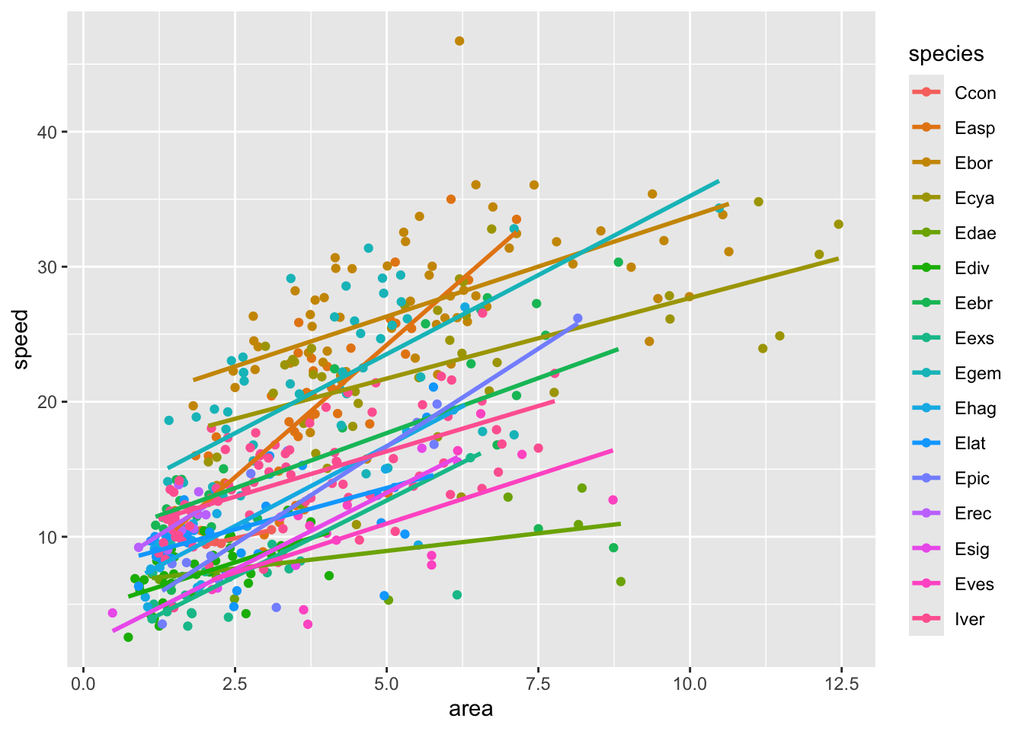

### step 2: simulate data

test if you can simulate data for the model & how well you get parameters back. a well running model = no divergences, Rhat close to 1, good Neffective.

some plots, looking at empirical data characteristics:

```r
length(unique(fastswim$species)) # 16 unique species
```

```
## [1] 16
```

```r
nrow(fastswim) # total 565 rows
```

```
## [1] 565
```

```r
fastswim %>%
  group_by(species) %>%
  summarise(n()) # number of obs per species, min=8, max=84
```

```
## # A tibble: 16 × 2
##    species `n()`
##    <chr>   <int>
##  1 Ccon        8
##  2 Easp       39
##  3 Ebor       63
##  4 Ecya       38
##  5 Edae       16
##  6 Ediv       55
##  7 Eebr       29
##  8 Eexs       41
##  9 Egem       49
## 10 Ehag       20
## 11 Elat       36
## 12 Epic       23
## 13 Erec        8
## 14 Esig       13
## 15 Eves       43
## 16 Iver       84
```

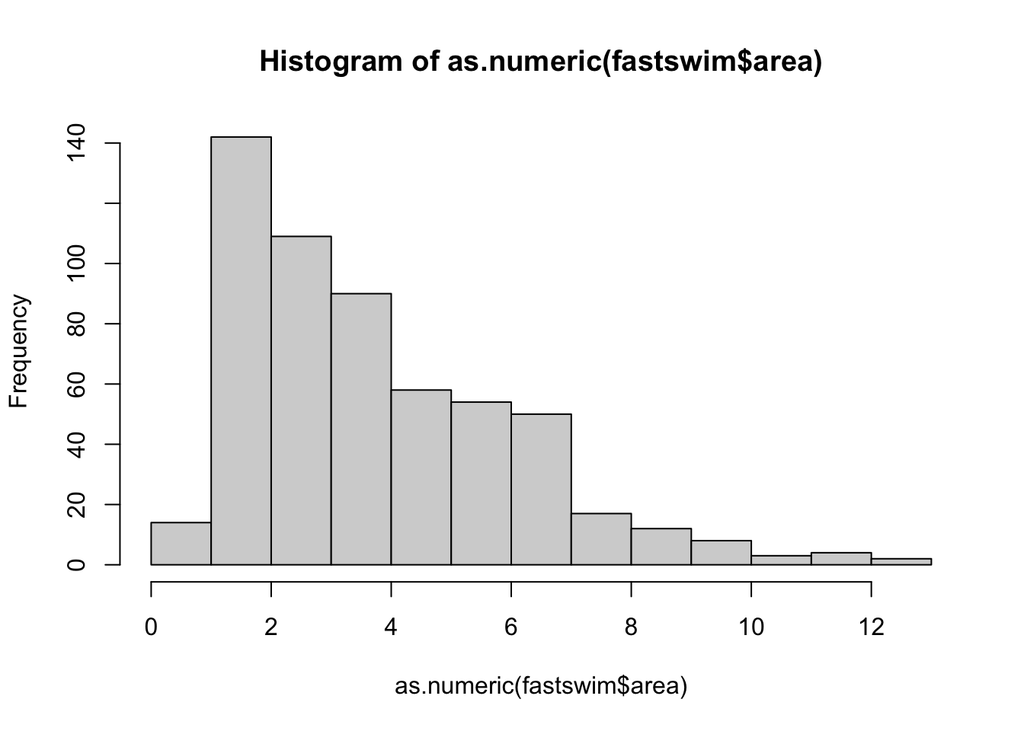

```r
hist(as.numeric(fastswim$area))
```

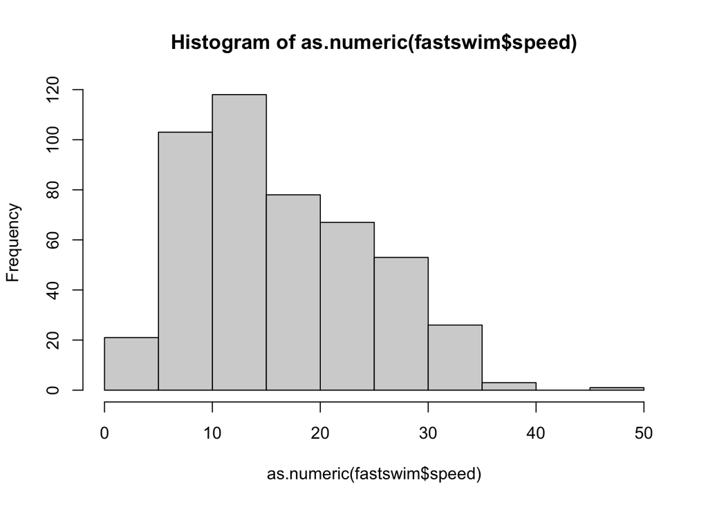

```r
hist(as.numeric(fastswim$speed))
```

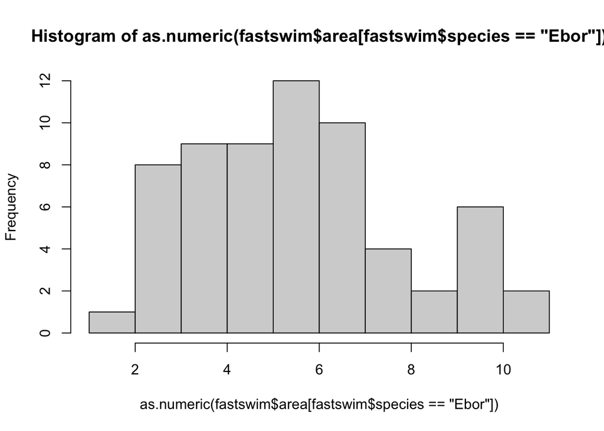

```r
hist(as.numeric(fastswim$area[fastswim$species=="Ebor"]))
```

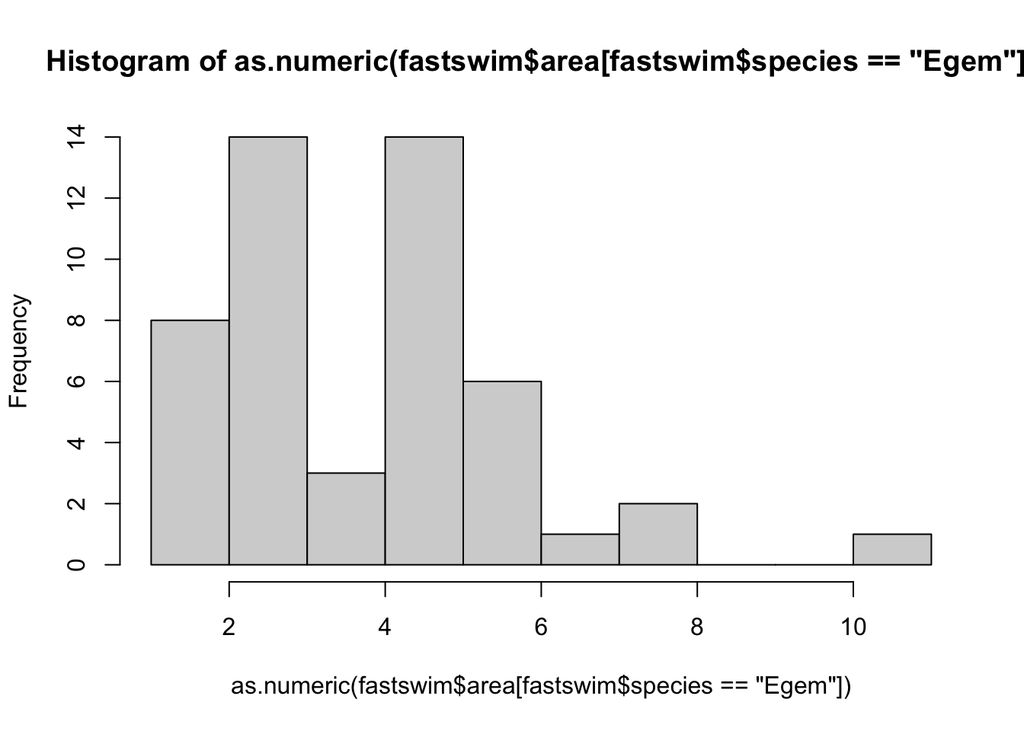

```r
hist(as.numeric(fastswim$area[fastswim$species=="Egem"]))
```

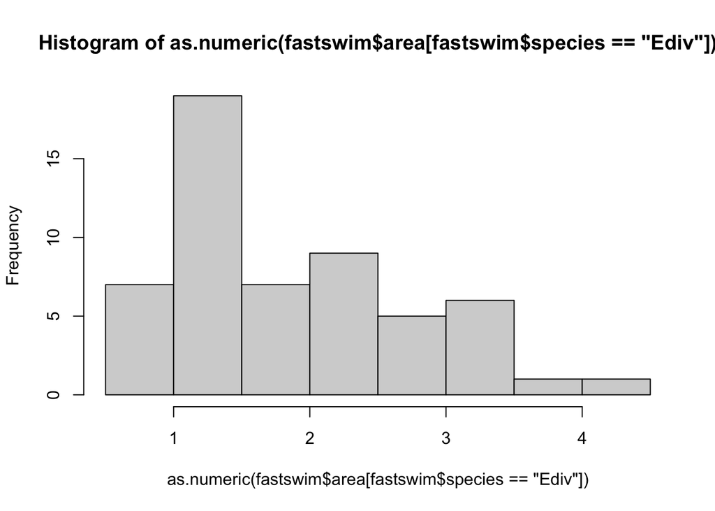

```r
hist(as.numeric(fastswim$area[fastswim$species=="Ediv"]))
```

simulate a dataset:

```r
# set number of spp
nspp <- 16

# set parameters
alphamu <- 7
alphasigma <- 3
betamu <- 2
betasigma <- 1
sigmay <- 5
parameters <- c(alphamu, alphasigma, betamu, betasigma, sigmay)

# set hyper priors
alphaspp <- rnorm(nspp, alphamu, alphasigma)
betaspp <- rnorm(nspp, betamu, betasigma)

# simulate dataset
obs_per_spp <- round(runif(nspp, 8, 84)) # the number of obs/reps per spp varies btwn min=8 & max=84
species_id <- rep(1:nspp, obs_per_spp) # make a vector of spp ID, rep'd by # of times they appear in df
n <- length(species_id) # length of the df
individual <- 1:n
area <- abs(rnorm(n, mean=4, sd=3)) # abs() wrapper so that no values are <0

# simulate y data
ypred <- rep(NA, n)

for(i in 1:n){
  sp <- species_id[i]   # set the species ID to get intercept + slope parameters
  ypred[i] <- alphaspp[sp] + betaspp[sp]*area[i] # i calls a given value in the vector, sp calls the appropriate spp ID corresponding to a hyper prior
}

# now set y (aka speed)
speed <- rnorm(n, ypred, sigmay)

# put everything in a df
sim_dat <- data.frame(species_id, individual, area, speed) %>%
  mutate(species_id = as.factor(species_id)) # change from numeric to factor
```

check simulated data by plotting:

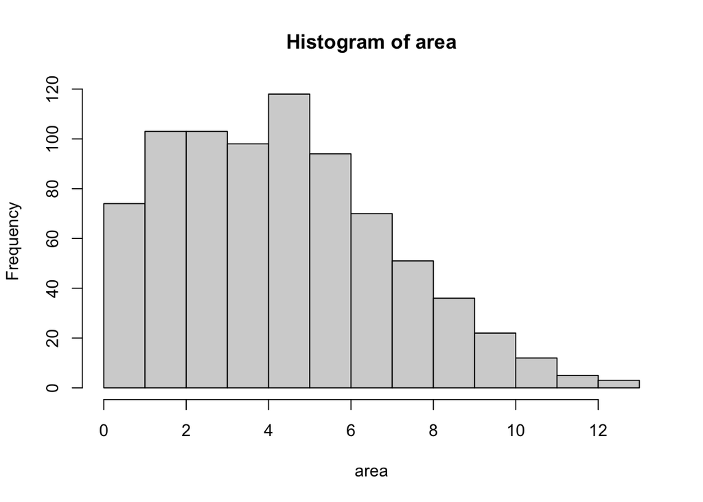

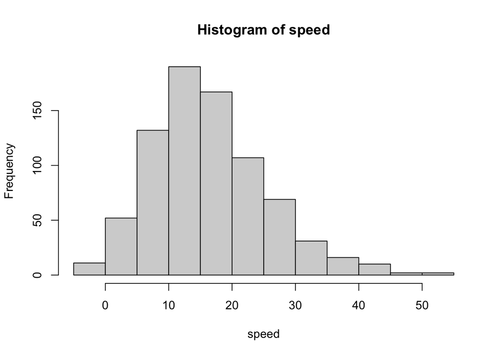

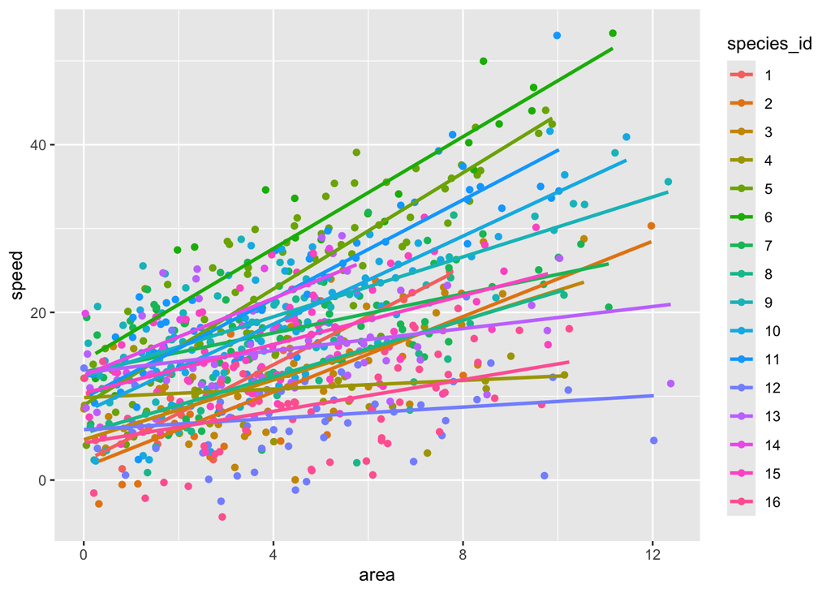

here i fit a model to my simulated data to see how well i recover parameters set above. generally the model ran well–there were no divergences and rhat=1.0 for all parameters.however, i was getting low n_eff using the default number of iterations (2000 iterations per chain pre warm up, 1000 per chain post warm up). so, i had to increase the number of pre-warm up iterations to 4000 per chain to get sufficient n_eff, which might indicate issues searching parameter space when there are fewer iterations. looking at the chain plots, i can tell there’s some issues searching parameter space (eg. flat spots), so i might consider increasing iterations more/increasing number of warm up iterations if i was actually going to use these models.

in terms of parameter estimates, the overall intercept and species slopes were well estimated, but the species-specific intercept estimates were quite poor. sigmay was better estimated than the hyper parameter sigmas.

reminder of parameter values alphamu <- 7 alphasigma <- 3 betamu <- 2 betasigma <- 1 sigmay <- 5

```r
# note: hiding results so it doesn't print big list
# random slopes AND intercept model
sim_mod <- stan_lmer(speed ~ area|species_id, data=sim_dat, iter=4000) # set 3000 instead of default 2000 iter per chain pre-warm up
summary(sim_mod)
```

```
##
## Model Info:
##  function:     stan_lmer
##  family:       gaussian [identity]
##  formula:      speed ~ area | species_id
##  algorithm:    sampling
##  sample:       8000 (posterior sample size)
##  priors:       see help('prior_summary')
##  observations: 789
##  groups:       species_id (16)
##
## Estimates:
##                                             mean   sd   10%   50%   90%
## (Intercept)                                8.5    1.6  6.5   8.5  10.5
## b[(Intercept) species_id:1]               -3.8    2.6 -7.2  -3.6  -0.5
## b[area species_id:1]                       2.3    0.6  1.6   2.3   3.0
## b[(Intercept) species_id:2]               -5.1    2.4 -8.1  -5.0  -2.1
## b[area species_id:2]                       1.9    0.4  1.4   1.9   2.4
## b[(Intercept) species_id:3]               -3.1    2.0 -5.6  -3.0  -0.6
## b[area species_id:3]                       1.7    0.3  1.3   1.7   2.0
## b[(Intercept) species_id:4]                1.0    2.0 -1.6   1.0   3.6
## b[area species_id:4]                       0.3    0.3 -0.1   0.3   0.7
## b[(Intercept) species_id:5]                0.6    1.9 -1.9   0.6   3.0
## b[area species_id:5]                       3.4    0.2  3.1   3.4   3.7
## b[(Intercept) species_id:6]                4.4    2.5  1.3   4.4   7.6
## b[area species_id:6]                       3.5    0.3  3.1   3.5   3.9
## b[(Intercept) species_id:7]                3.9    1.8  1.6   3.9   6.2
## b[area species_id:7]                       1.2    0.2  1.0   1.2   1.5
## b[(Intercept) species_id:8]               -2.2    2.1 -4.9  -2.1   0.4
## b[area species_id:8]                       1.5    0.3  1.2   1.5   1.9
## b[(Intercept) species_id:9]                3.5    1.9  1.2   3.5   5.9
## b[area species_id:9]                       1.8    0.2  1.6   1.8   2.1
## b[(Intercept) species_id:10]              -0.2    1.9 -2.6  -0.1   2.2
## b[area species_id:10]                      2.6    0.2  2.3   2.6   2.9
## b[(Intercept) species_id:11]               1.3    1.9 -1.2   1.3   3.7
## b[area species_id:11]                      2.9    0.2  2.7   2.9   3.2
## b[(Intercept) species_id:12]              -2.2    1.9 -4.6  -2.1   0.2
## b[area species_id:12]                      0.3    0.2  0.0   0.3   0.6
## b[(Intercept) species_id:13]               3.8    1.8  1.5   3.7   6.1
## b[area species_id:13]                      0.7    0.2  0.4   0.7   1.1
```

[output cut: 45 more lines]

```
## b[area species_id:13]                     0.0  1.0   9002
## b[(Intercept) species_id:14]              0.1  1.0   1486
## b[area species_id:14]                     0.0  1.0   7333
## b[(Intercept) species_id:15]              0.1  1.0    947
## b[area species_id:15]                     0.0  1.0  10021
## b[(Intercept) species_id:16]              0.1  1.0    944
## b[area species_id:16]                     0.0  1.0  10261
## sigma                                     0.0  1.0   8015
## Sigma[species_id:(Intercept),(Intercept)] 0.2  1.0   2201
## Sigma[species_id:area,(Intercept)]        0.2  1.0    632
## Sigma[species_id:area,area]               0.1  1.0   2151
## mean_PPD                                  0.0  1.0   8158
## log-posterior                             0.2  1.0   1466
##
## For each parameter, mcse is Monte Carlo standard error, n_eff is a crude measure of effective sample size, and Rhat is the potential scale reduction factor on split chains (at convergence Rhat=1).
```

```r
# launch_shinystan(sim_mod) # i looked at this!
alphaspp
```

```
##  [1]  6.770818  2.896288  3.173730  9.196774  8.472817 11.954685 13.452587
##  [8]  7.217589 10.898116  6.956281  9.275802  4.082332 10.836683 10.447447
## [15] 10.159817  3.446139
```

```r
betaspp
```

```
##  [1] 2.1814923 2.2382211 1.9894986 0.3877538 3.6181908 3.4702590 1.1638907
##  [8] 1.3442072 1.9366891 2.7488122 2.7496904 0.5393814 1.1061472 2.8755641
## [15] 1.5190436 0.9523207
```

### step 3 (optional): prior predictive checks

i think my betamu and betasigma values need to be decreased a smidge, and i need to make sure the speed > 0 always (i think this is the fault of the intercept prior). but i think that it’s probably that the relationship btwn area & speed is larger than 1:1, ie. that 1 unit increase in area should generate >1 unit increases in speed.

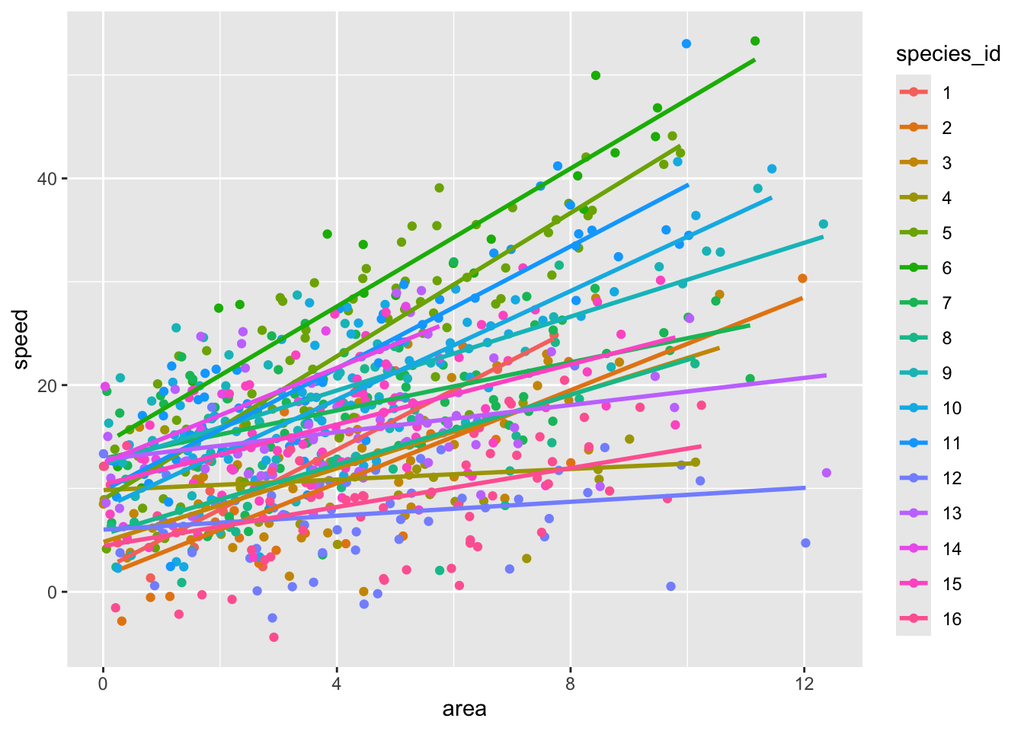

re-try with smaller betamu, betasigma, alphasigma parameters, but increase alphamu.

```r
# set number of spp
nspp <- 16

# set parameters
alphamu <- 12
alphasigma <- 1.5
betamu <- 1.7
betasigma <- 0.5
sigmay <- 5
parameters <- c(alphamu, alphasigma, betamu, betasigma, sigmay)

# set hyper priors
alphaspp <- rnorm(nspp, alphamu, alphasigma)
betaspp <- rnorm(nspp, betamu, betasigma)

# simulate dataset
obs_per_spp <- round(runif(nspp, 8, 84)) # the number of obs/reps per spp varies btwn min=8 & max=84
species_id <- rep(1:nspp, obs_per_spp) # make a vector of spp ID, rep'd by # of times they appear in df
n <- length(species_id) # length of the df
individual <- 1:n
area <- abs(rnorm(n, mean=4, sd=3)) # abs() wrapper so that no values are <0

# simulate y data
ypred <- rep(NA, n)

for(i in 1:n){
  sp <- species_id[i]   # set the species ID to get intercept + slope parameters
  ypred[i] <- alphaspp[sp] + betaspp[sp]*area[i] # i calls a given value in the vector, sp calls the appropriate spp ID corresponding to a hyper prior
}

# now set y (aka speed)
speed <- rnorm(n, ypred, sigmay)

# put everything in a df
sim_dat2 <- data.frame(species_id, individual, area, speed) %>%
  mutate(species_id = as.factor(species_id)) # change from numeric to factor
```

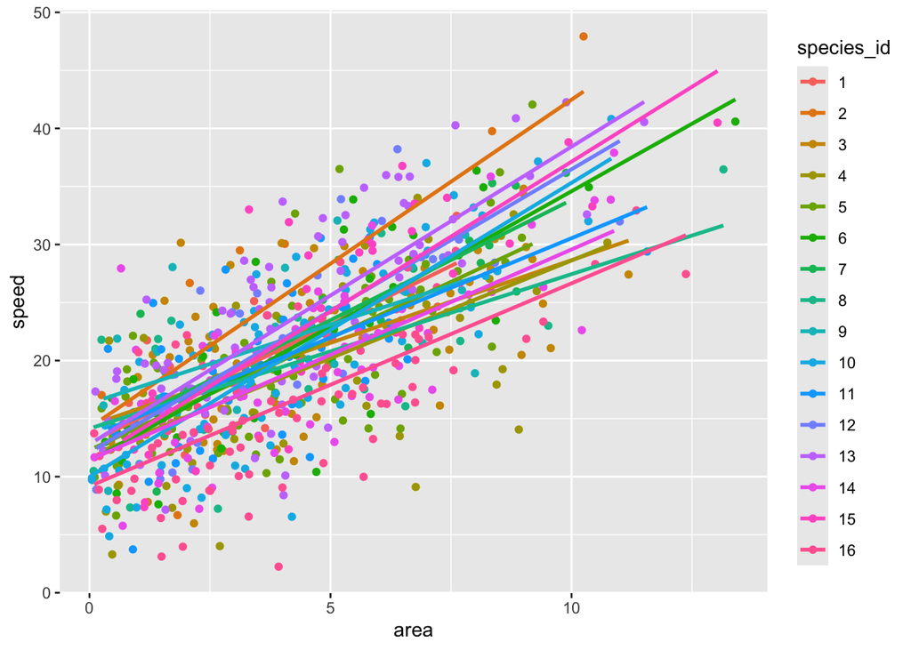

this looks much better.

now i will check each prior individually. alphamu <- 12 alphasigma <- 1.5 betamu <- 1.7 betasigma <- 0.5 sigmay <- 5

for slope parameter: i think this is reasonable–nothing below 0, and i think the variance is reasonable–ie a reasonable range is covered, without crazy high values (eg. i wouldn’t believe a slope >5).

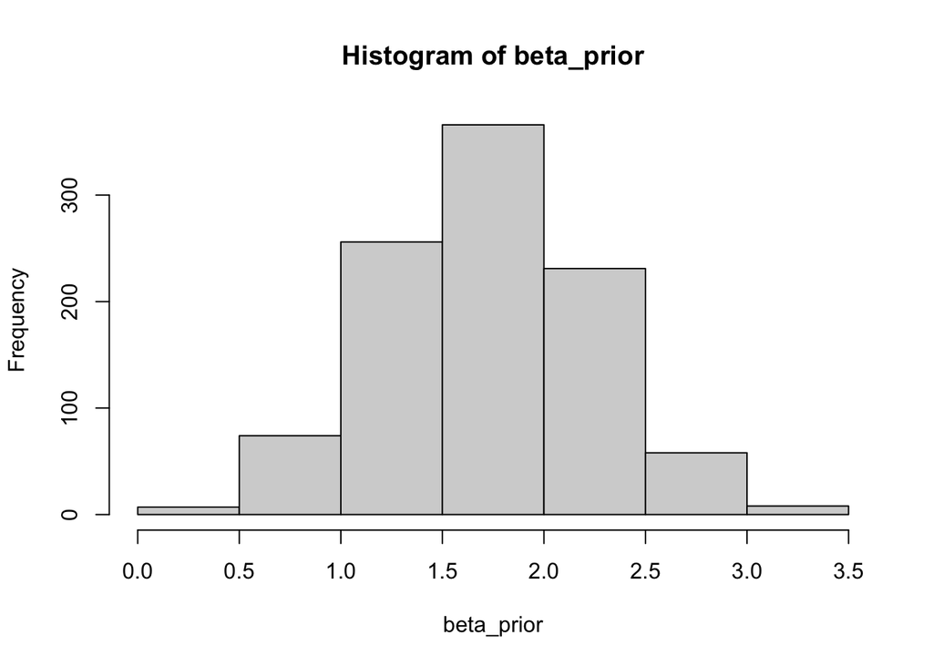

```r
reps_ppc <- 1000 # set the number of reps
beta_prior <- rnorm(reps_ppc, betamu, betasigma) # generate
hist(beta_prior) # plot
```

for intercept parameter: also feel good abt this (same reasoning as above).

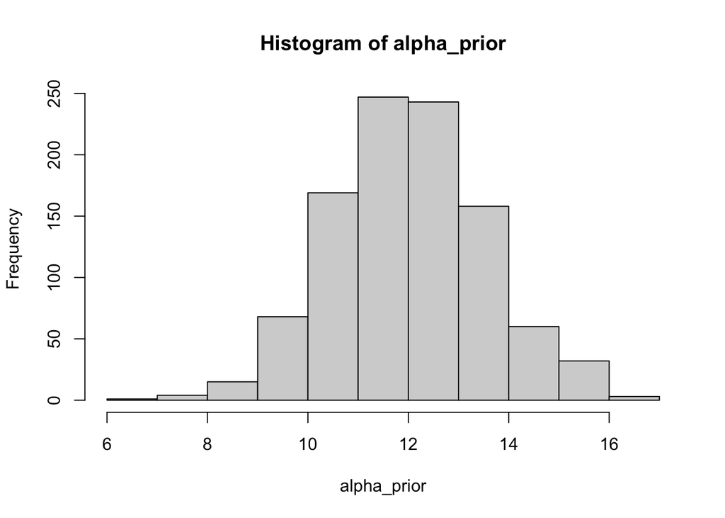

```r
reps_ppc <- 1000 # set the number of reps
alpha_prior <- rnorm(reps_ppc, alphamu, alphasigma) # generate
hist(alpha_prior) # plot
```

for sigmay parameter: i’m not really sure what the sigma of my sigmaymu is…but this seems to be a good range?? i wouldn’t believe a sigmay value above 8…

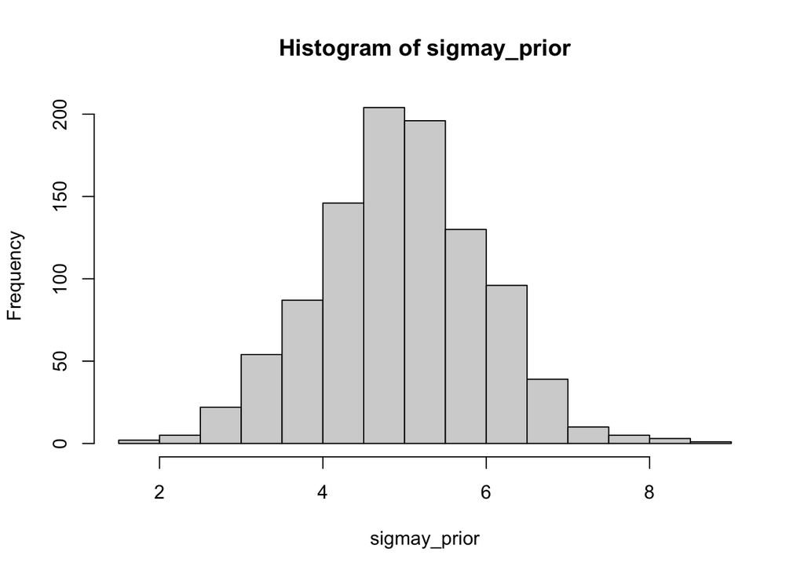

```r
sigmay_mu <- 5
sigmay_sigma <- 1
reps_ppc <- 1000 # set the number of reps
sigmay_prior <- rnorm(reps_ppc, sigmay_mu, sigmay_sigma) # generate
hist(sigmay_prior) # plot
```

i will continue with the prior values: alphamu <- 12 alphasigma <- 1.5 betamu <- 1.7 betasigma <- 0.5 sigmay <- 5

### step 4: run model with empirical data

a well running model = no divergences, Rhat close to 1, good Neffective.

rhat ok, but i was having trouble getting high enough n_eff and had some warnings of divergent transitions, so i upped the iteration & warmup values.

```r
# note: hiding results so it doesn't print big list

fastswim <- fastswim %>%
  mutate(species = as.factor(species),  # make sure grouping var is factor, x & y are numeric
         speed = as.numeric(speed),
         area = as.numeric(area))

emp_mod <- stan_lmer(speed ~ area|species, data=fastswim, iter=6000, warmup=4000) # set iterations to 4000, i know that i need for decent n_eff
```

```
## Warning: There were 1 divergent transitions after warmup. See
## https://mc-stan.org/misc/warnings.html#divergent-transitions-after-warmup
## to find out why this is a problem and how to eliminate them.
```

```
## Warning: Examine the pairs() plot to diagnose sampling problems
```

inspect output:

```r
summary(emp_mod)
```

```
##
## Model Info:
##  function:     stan_lmer
##  family:       gaussian [identity]
##  formula:      speed ~ area | species
##  algorithm:    sampling
##  sample:       8000 (posterior sample size)
##  priors:       see help('prior_summary')
##  observations: 469
##  groups:       species (16)
##
## Estimates:
##                                          mean   sd    10%   50%   90%
## (Intercept)                              9.7    1.9   7.3   9.7  12.1
## b[(Intercept) species:Ccon]             -0.4    4.2  -5.7  -0.2   4.8
## b[area species:Ccon]                     0.2    1.6  -1.9   0.2   2.2
## b[(Intercept) species:Easp]             -4.0    2.8  -7.6  -4.0  -0.5
## b[area species:Easp]                     3.6    0.5   3.0   3.6   4.2
## b[(Intercept) species:Ebor]              8.5    2.2   5.7   8.5  11.3
## b[area species:Ebor]                     1.6    0.2   1.3   1.6   1.9
## b[(Intercept) species:Ecya]              5.4    2.3   2.6   5.4   8.4
## b[area species:Ecya]                     1.3    0.2   1.0   1.3   1.5
## b[(Intercept) species:Edae]             -2.7    2.7  -6.2  -2.6   0.7
## b[area species:Edae]                     0.4    0.4  -0.1   0.4   0.9
## b[(Intercept) species:Ediv]             -4.6    2.5  -7.8  -4.6  -1.5
## b[area species:Ediv]                     1.2    0.7   0.3   1.2   2.1
## b[(Intercept) species:Eebr]             -0.2    2.2  -2.9  -0.1   2.6
## b[area species:Eebr]                     1.6    0.3   1.3   1.6   1.9
## b[(Intercept) species:Eexs]             -7.3    2.5 -10.6  -7.3  -4.1
## b[area species:Eexs]                     2.0    0.5   1.4   2.0   2.6
## b[(Intercept) species:Egem]              2.0    2.3  -0.8   2.0   4.9
## b[area species:Egem]                     2.3    0.3   2.0   2.4   2.7
## b[(Intercept) species:Ehag]             -4.3    2.4  -7.4  -4.2  -1.2
## b[area species:Ehag]                     2.2    0.5   1.6   2.2   2.8
## b[(Intercept) species:Elat]             -2.0    2.3  -4.9  -2.0   0.8
## b[area species:Elat]                     1.2    0.4   0.6   1.2   1.7
## b[(Intercept) species:Epic]             -6.0    2.9  -9.8  -6.0  -2.3
## b[area species:Epic]                     2.6    0.5   1.9   2.5   3.2
## b[(Intercept) species:Erec]              0.2    3.5  -4.3   0.3   4.5
## b[area species:Erec]                     0.8    1.8  -1.5   0.8   3.0
```

[output cut: 45 more lines]

```
## b[area species:Erec]                   0.0  1.0   5721
## b[(Intercept) species:Esig]            0.1  1.0   1674
## b[area species:Esig]                   0.0  1.0   9660
## b[(Intercept) species:Eves]            0.1  1.0   1561
## b[area species:Eves]                   0.0  1.0   8816
## b[(Intercept) species:Iver]            0.1  1.0    770
## b[area species:Iver]                   0.0  1.0  11083
## sigma                                  0.0  1.0   7820
## Sigma[species:(Intercept),(Intercept)] 0.4  1.0   1670
## Sigma[species:area,(Intercept)]        0.2  1.0    738
## Sigma[species:area,area]               0.0  1.0   2658
## mean_PPD                               0.0  1.0   8288
## log-posterior                          0.1  1.0   1730
##
## For each parameter, mcse is Monte Carlo standard error, n_eff is a crude measure of effective sample size, and Rhat is the potential scale reduction factor on split chains (at convergence Rhat=1).
```

```r
# launch_shinystan(emp_mod) # i looked at this!
```

### step 5 (optional): retrodictive checks

did not do this step.